# Bayesian Data Analysis Project

## 1. Abstract

## 2. Introduction

### a) Background

Beta-carotene is a natural pigment found in plants, giving them their orange colors. It is a provitamin A, meaning the body uses it to make vitamin A, which is essential for maintaining healthy vision, skin, and immune function. However, high doses over a long time can lead to a condition called carotenemia, resulting in a yellowish-orange tint to the skin.

Pharmacokinetic studies, also known as PK studies, are a type of research in pharmacology to investigate the effect of the body on a drug. One common topic for PK studies is how a drug builds up in bloodstream over time. These type of studies collecting blood, to measure the concentration of the drug in the blood plasma. In this study, researchers investigated the concentration of Beta-carotene in 46 patients who received different doses of the treatment. This data helps researchers to understand how Beta-carotene behaves in the body over time, providing valuable insights for clinical practice.

### b) Questions of Interest

The specific aim of this study is to (1) determine how different dose levels of beta-carotene affected the serum beta-carotene levels in blood over time. In addition to measuring the plasma concentrations of beta-carotene by dose, we are also interested in examining (2) whether there is any effect of beta-carotene supplementation on vitamin E levels in the plasma. Since both beta carotene and vitamin E are lipid soluble (they are dissolved in fats rather than water), it might be possible that serum vitamin E levels are correlated with serum beta-carotene levels over time. We are also interested in (3) whether there are interactions between treatment and age, gender, BMI, or cholesterol.

## 3. Materials and Methods:

### (a) Source of Data

In this dataset, there are 46 volunteers who were randomly assigned to receive one of five doses of beta-carotene (0, 15, 30, 45, or 60 mg/day) for up to 15 months in a double-blind manner. Each volunteer’s progress was monitored monthly, resulting in a total of 699 observations. The dataset contains 11 variables for each observation: *ptid* (patient ID): a unique identification number assigned to each of the 46 patients, *month*: Indicates the month of the study, with values ranging from 0 to 15. Months 0 to 3 serve as a baseline, and the beta-carotene treatment begins at month 4. Note that some patients have fewer than 15 months of data. *bcarot* (Plasma beta-carotene levels): the concentration of beta-carotene in the patient’s blood, measured in micrograms per milliliter. *vite* (Plasma vitamin E levels): The concentration of vitamin E in the patient’s blood, measured in micrograms per milliliter. *dose* (Dose of beta-carotene): The amount of beta-carotene administered to the patient daily as part of the treatment. *age*: The age of the patient. *male*: An indicator variable that denotes the patient’s gender. *bmi*: (Body Mass Index): A measure of the patient’s body weight in relation to their height. *chol*: (Serum cholesterol level): The level of cholesterol in the patient’s blood, measured in milligrams per deciliter *cauc* (Area under curve for serum beta-carotene): The average level of serum beta-carotene over the months 4 and onwards. *vauc* (Area under curve for serum vitamin E): The average level of serum vitamin E over the months 4 and onwards.

Patient number 46 showed an unusual increase in beta-carotene levels at month 4, reaching 2452 ($\mu g/ml$), which is significantly higher than the average baseline level of 297.37 ($\mu g/ml$). Although the levels returned to normal after month 10, this behavior led us to remove this patient from the study. Patient number 40 was excluded from the study as he only participated in the baseline period, without taking any treatment. Patient number 24, initially categorized in the placebo group with a dose of 0, unexpectedly received a dose of 30 only at month 0. Considering the preceding patient (ptid 23) was assigned to the dose 30 group, this inconsistency seems to be a typographical error therefore, we corrected the dose to 0. For some patients, we have two sets of data at the same month regarding their beta-carotene. We have decided to retain both values for our analysis. Patient 26 which is in placebo group (zero dose) shows an unusual behavior in their beta-carotene level during the 13th month, recording a value of 1014. This value stood out as it was higher than both the preceding month’s value of 114 and the next month’s value of 218. We have decided to retain this data point in our analysis. Additionally, we identified and removed six missing values from the dataset which seems randomly distributed through the data.

It is important to note that we tried to estimate the missing value by using the Area Under the Curve (AUC) calculations, for the *cauc* and *vauc* variable, available in the dataset. However, due to the existence of multiple methods and formulas for AUC calculation, we could not find any approach that resulted in an AUC value consistent with our dataset. Therefore, further investigation about the origin of data (AUC formula) is necessary for this analysis.

### (b) Statistical Methods:

## 4. Results

### (a) Descriptive Statistics:

The beta-carotene levels shows an increase during the first month of treatment (month 4 in original data), followed by a decrease after the ninth month. Therefore, using a quadratic linear regression model seems to be a suitable approach for fitting this data.

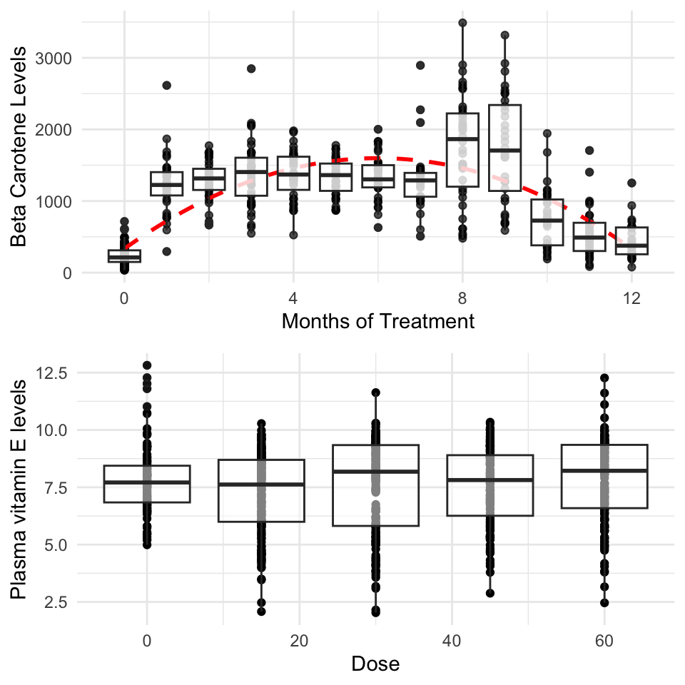

Fitted quadratic regression for Beta Carotene Levels over time following treatment initiation (top). Boxplot displays the spread of Plasma Vitamin E levels across different doses of beta-carotene. (bottom)

### (b) Models

The specific aim of this study is to determine how different dose levels of beta-carotene affected the serum beta-carotene levels in blood over time. for this part we fit the following model:

$$\begin{equation}
\begin{gathered}
\text{BetaCarotine}^{(i)} = \beta_0 + \beta_1 (\text{dose}^{(i)}) +
\beta_2 (\text{month}^{(i)}) + \beta_3 ({\text{month}^2}^{(i)}) +
\beta_4 (\text{age}^{(i)}) \\
+\beta_5 I(\text{male}^{(i)}) + \beta_6 (\text{bmi}^{(i)}) + \beta_7
(\text{cholestrol}^{(i)}) + \epsilon^{(i)}
\end{gathered}
\end{equation}$$

for the above model we have run the Gibbs sampling and we got the following distribution for each parameters.

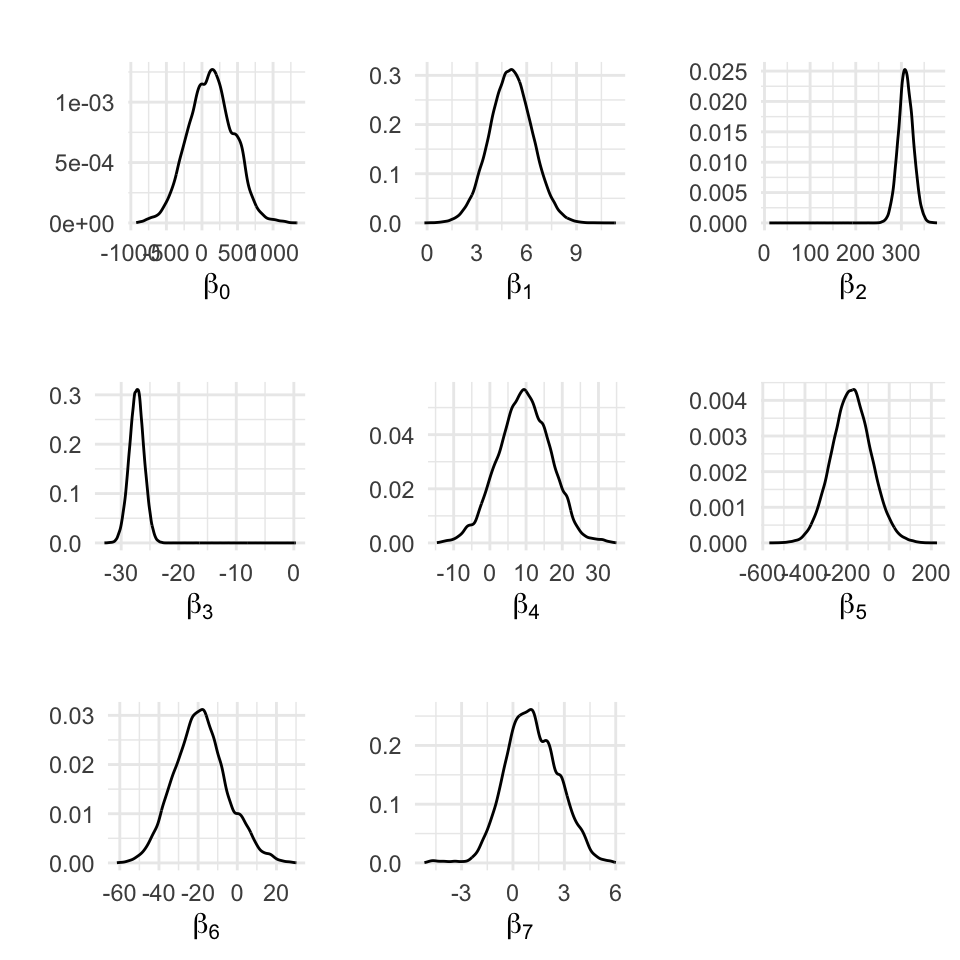

Posterior distribution for each parameters for model 1

to answer if there is any effect of beta-carotene supplementation on vitamin E levels in the plasma we use simple linear regresion model:

$$\begin{equation}
\begin{gathered}
\text{vitaminE}^{(i)} = \beta_0 + \beta_1 (\text{dose}^{(i)}) +
\epsilon^{(i)}
\end{gathered}
\end{equation}$$

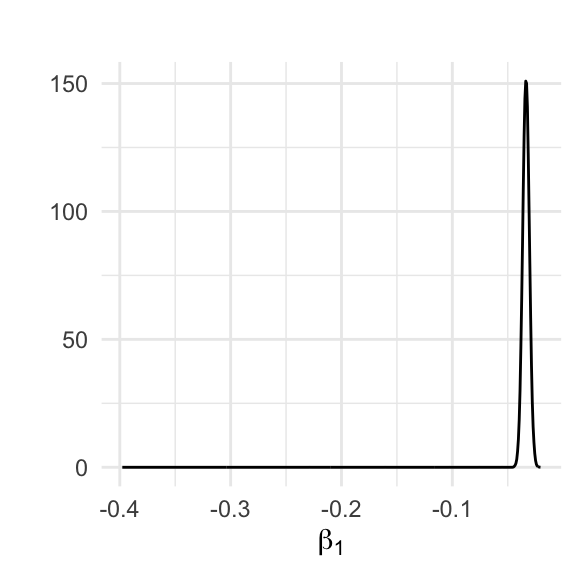

Posterior distribution for each parameters for model 2

In conclusion, the negative slope of $\beta_1$ suggests that with an increase in dosage, we anticipate lower vitamin E levels, which contradicts our initial expectations. Therefore, we recommend further analysis to better understand this unexpected result.

### (c) Model-Building / Model-Checking:

we assume (or maybe check) the ovariate are independence.

## 5. Discussion:

## 6. Bibliography:

## 7. Appendix:

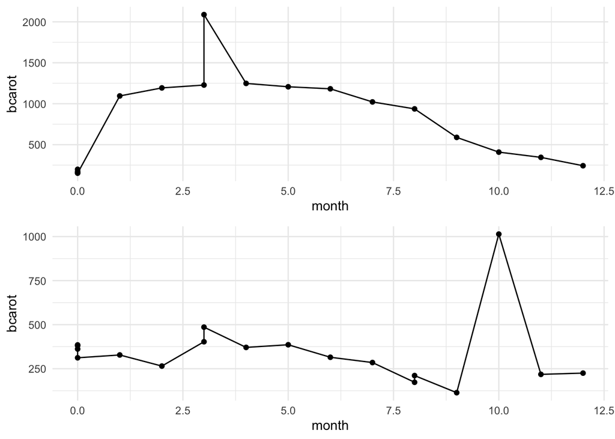

Beta Carotin behavier for patient 1 (top) and patient 26 (bottom) during treatment period

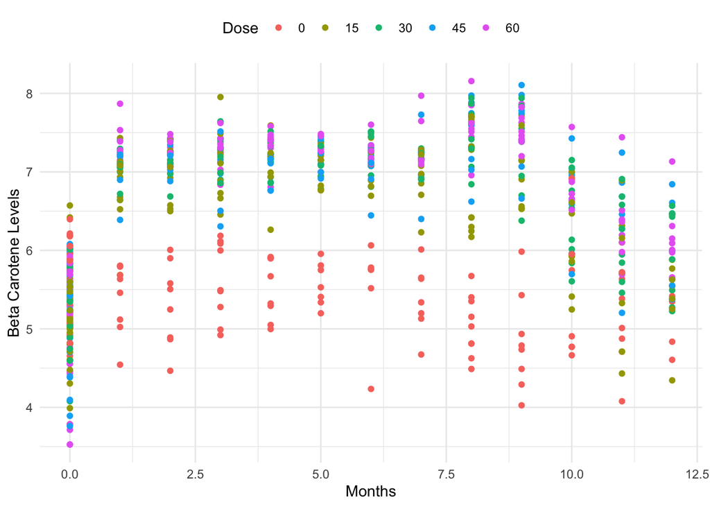

```r
ggplot(data = bc_data,
       aes(x = month,
           y = log(bcarot),
           group = ptid,
           col = as.factor(dose))) +
    geom_point() +
    theme_minimal()+
    labs(x = "Months",
         y = "Beta Carotene Levels",
         col = "Dose")+
    theme(legend.position = "top")
```

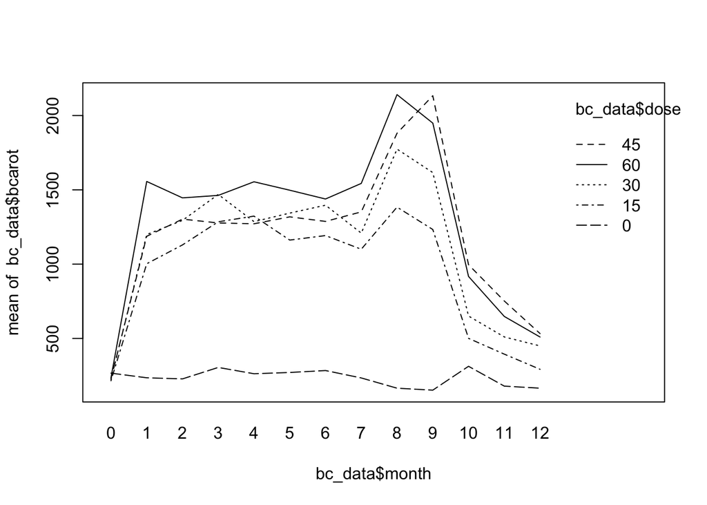

```r
interaction.plot(response = bc_data$bcarot , bc_data$month,bc_data$dose)
```

In the field of pharmacokinetics, the area under the curve (AUC) is the definite integral of the concentration of a drug in blood plasma as a function of time (this can be done using liquid chromatography–mass spectrometry[1]). In practice, the drug concentration is measured at certain discrete points in time and the trapezoidal rule is used to estimate AUC. In pharmacology, the area under the plot of plasma concentration of a drug versus time after dosage (called “area under the curve” or AUC) gives insight into the extent of exposure to a drug and its clearance rate from the body. The AUC (from zero to infinity) represents the total drug exposure across time.

In this dataset, there are 46 volunteers who were randomly assigned to receive one of five doses of beta-carotene (0, 15, 30, 45, or 60 mg/day) for up to 16 months in a double-blind manner. Each volunteer’s progress was monitored monthly, resulting in a total of 699 observations.

The dataset contains 11 variables for each observation: *ptid* (patient ID): a unique identification number assigned to each of the 46 patients, *month*: Indicates the month of the study, with values ranging from 0 to 15. We interpret this to be categorical where each number represents a whole calendar month so that there are a total of 16 months of observations. The first four months (0 to 3) serve as a baseline, and the beta-carotene treatment begins at the month labelled 4. Note that some patients have fewer than 16 months of data due to dropout. *bcarot* (Plasma beta-carotene levels): the concentration of beta-carotene in the patient’s blood, measured in micrograms per milliliter. *vite* (Plasma vitamin E levels): The concentration of vitamin E in the patient’s blood, measured in micrograms per milliliter. *dose* (Dose of beta-carotene): The amount of beta-carotene administered to the patient daily as part of the treatment. *age*: The age of the patient. *male*: An indicator variable that denotes the patient’s gender. *bmi*: (Body Mass Index): A measure of the patient’s body weight in relation to their height. *chol*: (Serum cholesterol level): The level of cholesterol in the patient’s blood, measured in milligrams per deciliter *cauc* (Area under curve for serum beta-carotene): The average level of serum beta-carotene over the months 4 and onwards. *vauc* (Area under curve for serum vitamin E): The average level of serum vitamin E over the months 4 and onwards.

*Patient number 46* showed an unusual increase in beta-carotene levels at month 4, reaching 2452 ($\mu g/ml$), which is significantly higher than the average baseline level of 297.37 ($\mu g/ml$). Although the levels returned to normal after month 10, this behavior led us to remove this patient from the study. *Patient number 40* was excluded from the study as he only participated in the baseline period, without taking any treatment. *Patient number 24*, initially categorized in the placebo group with a dose of 0, unexpectedly received a dose of 30 only at month 0. Considering the preceding patient (ptid 23) was assigned to the dose 30 group, this inconsistency seems to be a typographical error therefore, we corrected the dose to 0. For some patients, we have two sets of data at the same month regarding their beta-carotene. We have decided to retain both values for our analysis. *Patient 26* which is in placebo group (zero dose) shows an unusual behavior in their beta-carotene level during the 13th month, recording a value of 1014. This value stood out as it was higher than both the preceding month’s value of 114 and the next month’s value of 218. We have decided to retain this data point in our analysis.

We identified and removed six missing values from the dataset which seems randomly distributed through the data. We tried to impute the missing value by using the Area Under the Curve (AUC) calculations using the *cauc* and *vauc* variable, however we could not reproduce existing AUC values so did not follow through with this method.

### (b) Statistical Methods:

## 4. Results

### (a) Descriptive Statistics:

To explore the primary aim of the study to examine how treatment affects serum beta carotene levels, we plotted a line graph of serum beta carotene levels against months for each patient. This information is also presented in a time series of box blots faceted by the dosage level. For the control of zero dosage level, there is no change in beta carotene level with time. For the other positive dosage levels, serum beta carotene is close to zero, and then during the treatment period the serum values increase. It appears that the change from baseline serum levels is greater for larger dosage values on average.

Across the positive dosages treatment levels and while patients are on treatment after month 3, there appears to be constant serum levels until month 10, after which a spike occurs during months 11 and 12, which is then followed b a sharp decrease in months 13, 14, and 15.

### (c) Model-Building / Model-Checking:

we assume (or maybe check) the ovariate are independence.

## 5. Discussion:

## 6. Bibliography:

## 7. Appendix:

### Plots

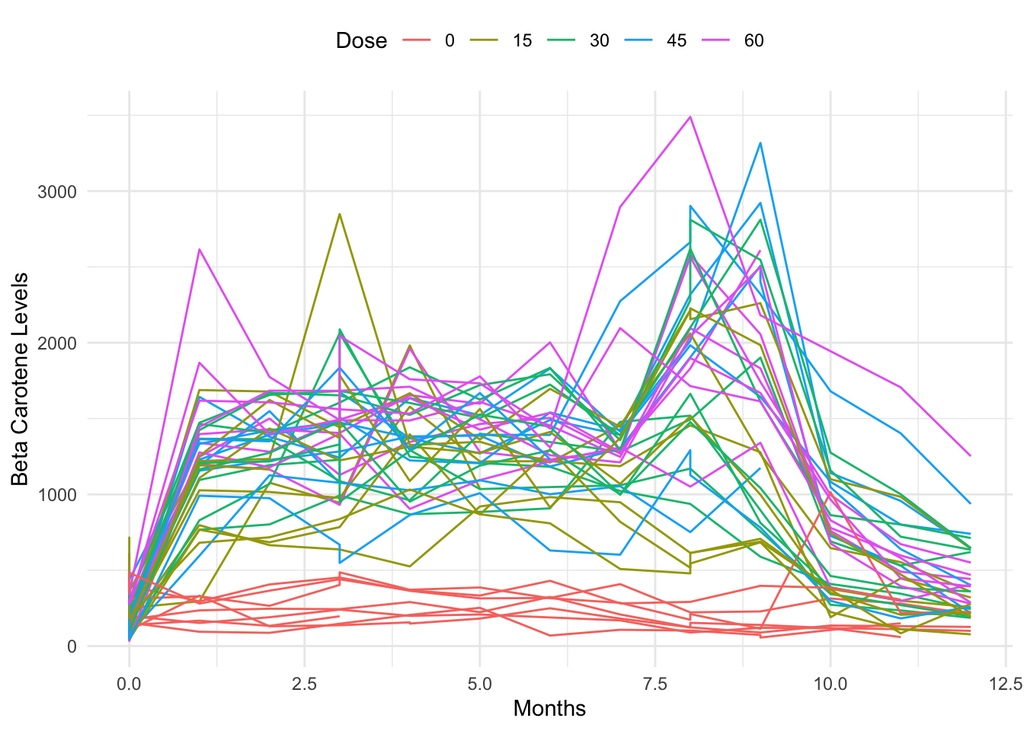

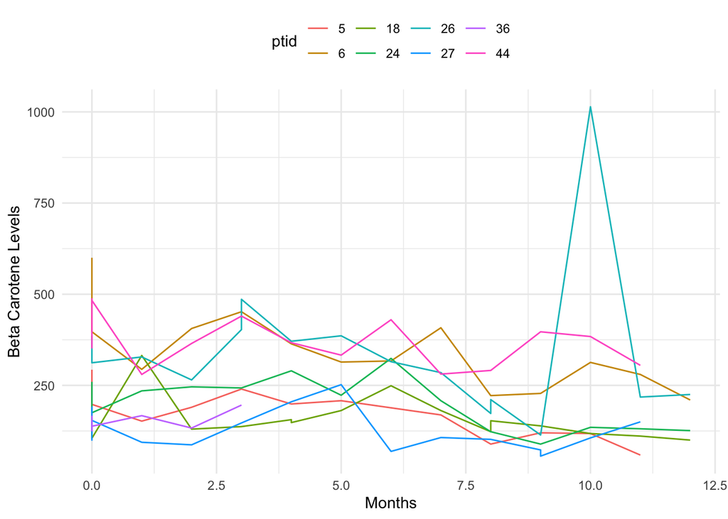

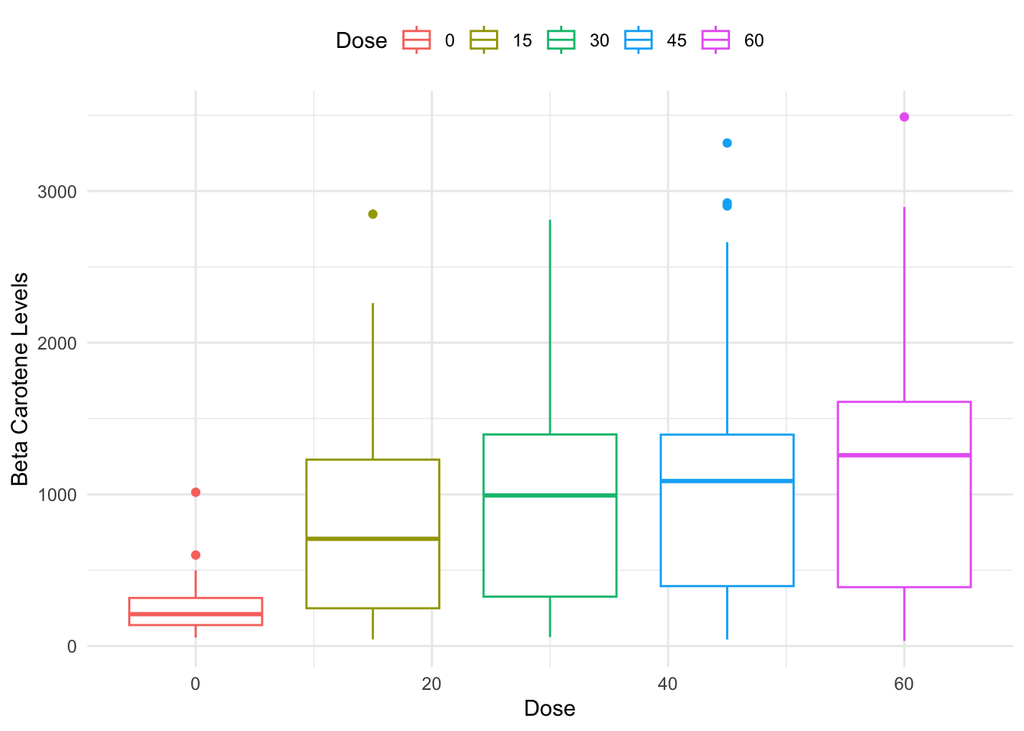

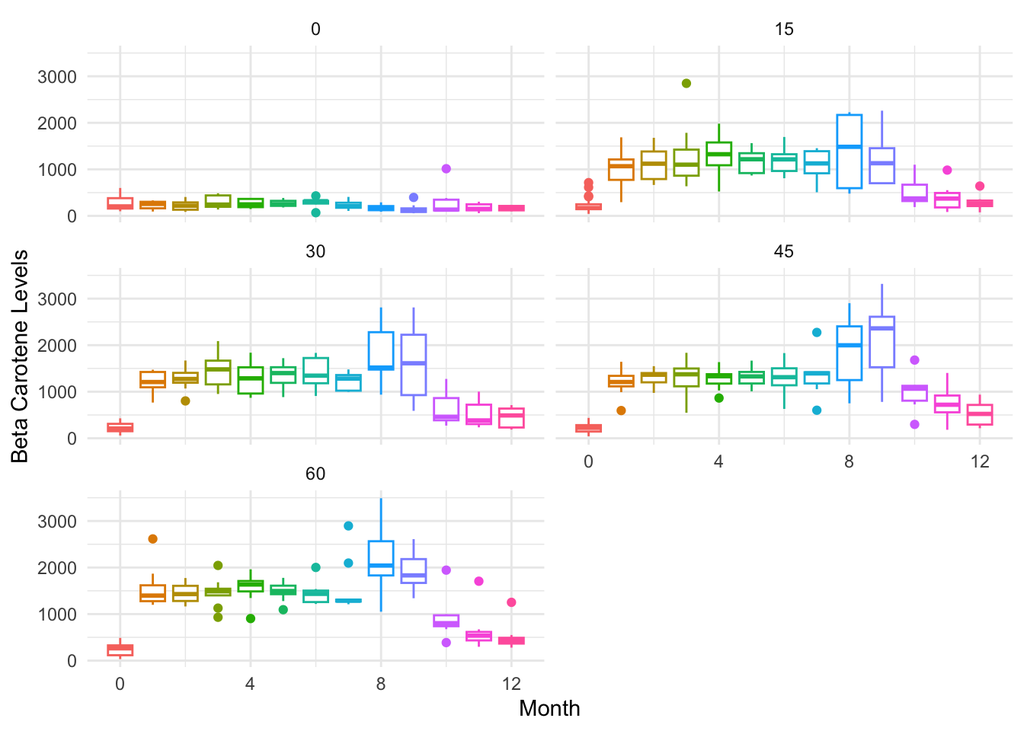

Models

```r
##  Set MCMC parameters.
chains <- 1           ##  One chain of MCMC values is obtained
burn_in <- 1000       ##  The first 1000 iterates from the MCMC chain are discarded
iterations <- 100000   ##  10,000 values are sampled from the posterior distribution
thin <- 1             ##  No thinning is performed


##  Define new variables for JAGS to use.
n <- dim(bc_data)[1]
n_patients <- length( unique(ptid) )

intercept <- rep(1,n)
tx <- intercept - (month<4)


##  Define the design matrix for the model and specify the number of covariates, for use in JAGS.
x <- cbind(intercept, tx*dose, vite, month, age, bmi, chol, cauc, vauc)
n_covariates <- dim(x)[2]
tau_b <- 0.00001


##  Establish data and parameter lists for use with OpenBUGS; define function for generating initial parameter values.
data <- list( "bcarot"=bcarot,
              "n"=n,
              "n_patients"=n_patients,
              "n_covariates"=n_covariates,
              "ptid"=ptid,
              "x"=x,
              "tau_b"=tau_b )

inits <- function() {
  list( beta = rnorm( n_covariates, 0, 1 ),
        gamma = rnorm( n_patients, 0, 1 ),
        tau_bc = runif( 1, 0, 2 ),
        tau_g = runif( 1, 0, 2 ) )
}

parameters <- c( "beta", "gamma", "sigma_bc", "sigma_g" )



###############   CREATE MODEL   ###############

bc_modelstring<-"model
  {
    for(i in 1:n){
        bcarot[i] ~ dnorm( mu[i], tau_bc )
          mu[i] <- inprod( x[i,], beta[] ) + gamma[ ptid[i] ]
    }
      for(j in 1:n_patients){
        gamma[j] ~ dnorm( 0, tau_g )
      }
    for(k in 1:n_covariates){
          beta[k] ~ dnorm( 0, tau_b )
      }
    tau_bc ~ dgamma(0.001, 0.001)
      tau_g ~ dgamma(0.001, 0.001)

    sigma_bc <- pow(tau_bc,-0.5)
      sigma_g <- pow(tau_g,-0.5)
  }"

beta_carotene.m <- jags.model( data=data,
                               inits=inits,
                               file=textConnection(bc_modelstring),
                               n.chains=chains )
beta_carotene.sim <- coda.samples(beta_carotene.m,
                                  parameters,
                                  n.iter=iterations,
                                  thin=thin,
                                  n.burn=burn_in)

## Assign variable names to posterior samples.
beta_carotene.iterates <- as.matrix(beta_carotene.sim)
beta_carotene.iterates <- as.data.frame(beta_carotene.iterates)

posterior_betas <- beta_carotene.iterates[,(1:n_covariates)]
names(posterior_betas) <- c("intercept", "dose", "vite", "month", "age", "bmi", "chol", "cauc", "vauc")
posterior_gammas <- beta_carotene.iterates[,((n_covariates+1):(n_covariates+n_patients))]
posterior_sigmas <- beta_carotene.iterates[,((n_covariates+n_patients+1):(n_covariates+n_patients+2))]
```

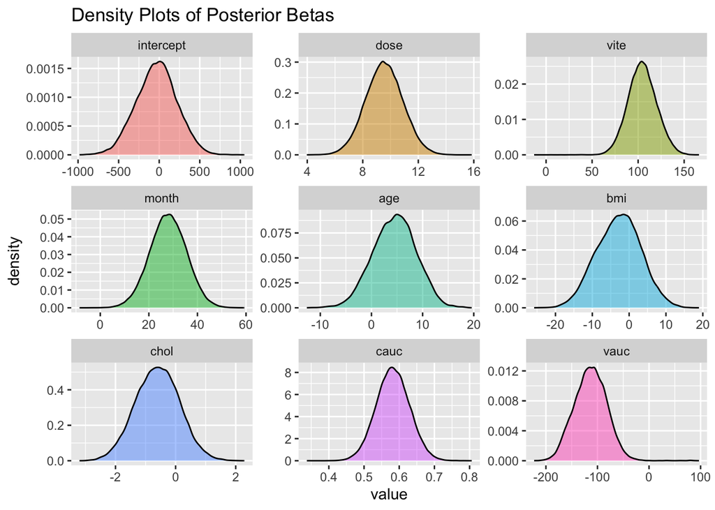

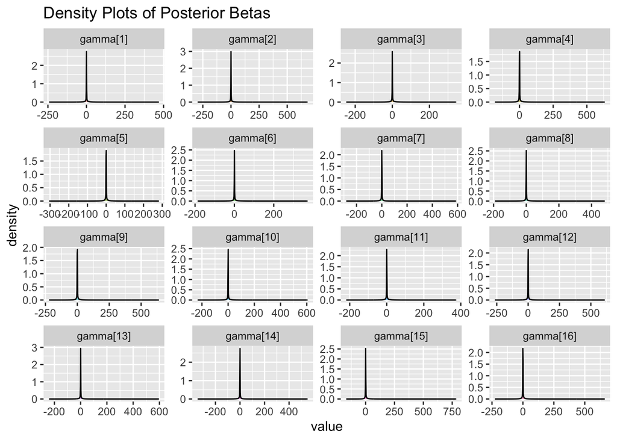

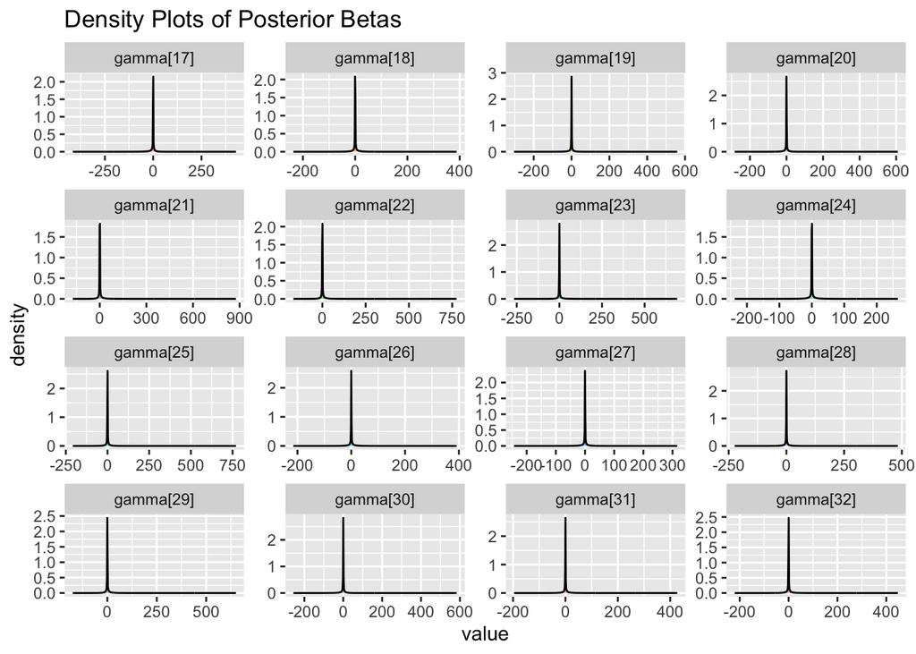

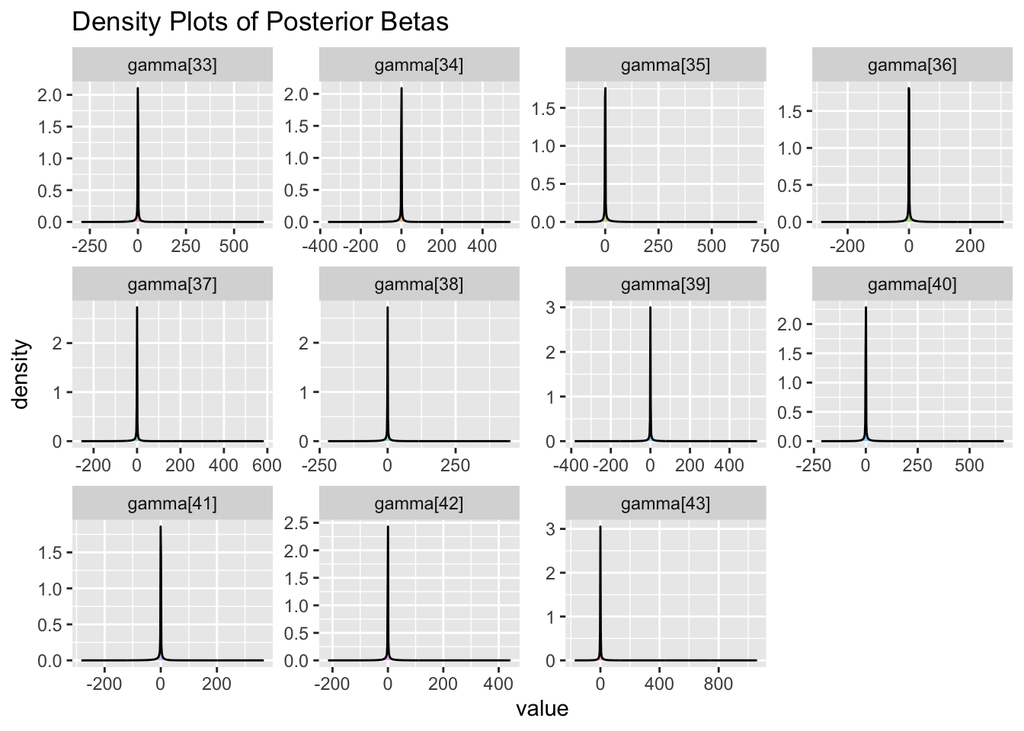

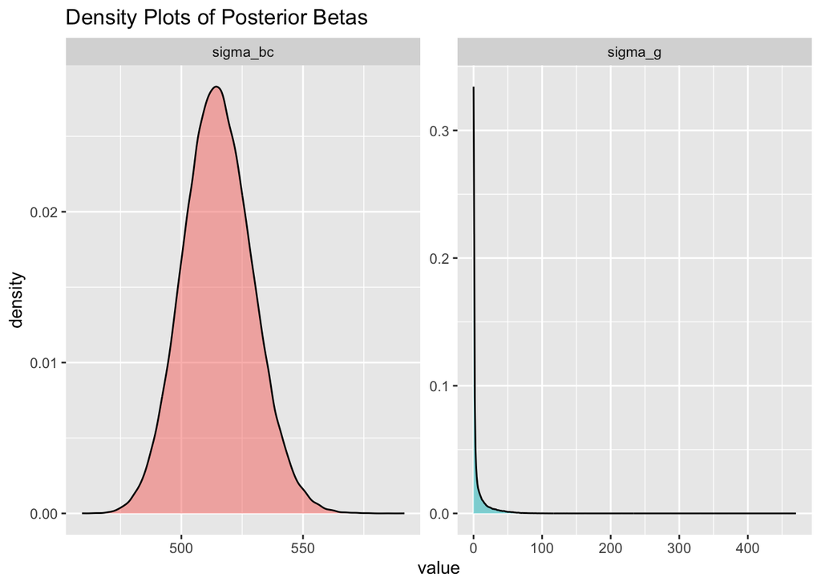

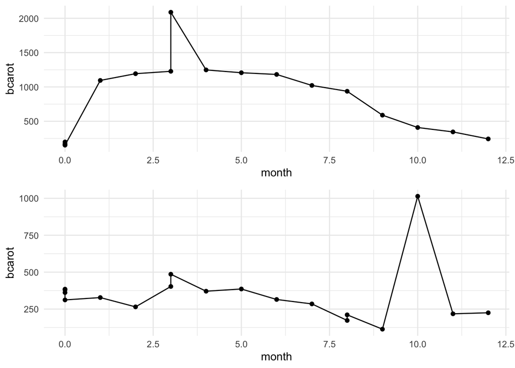

Beta Carotin behavier for patient 1 (top) and patient 26 (bottom) during treatment period

In the field of pharmacokinetics, the area under the curve (AUC) is the definite integral of the concentration of a drug in blood plasma as a function of time (this can be done using liquid chromatography–mass spectrometry[1]). In practice, the drug concentration is measured at certain discrete points in time and the trapezoidal rule is used to estimate AUC. In pharmacology, the area under the plot of plasma concentration of a drug versus time after dosage (called “area under the curve” or AUC) gives insight into the extent of exposure to a drug and its clearance rate from the body. The AUC (from zero to infinity) represents the total drug exposure across time.